# Assignment-2

Adriana LH

9/14/2020

My variables were:

1. Population totals per census tract with access to internet [continuous]
2. Median age in each census tract [continuous]
3. Total population of each census tract [continuous]
4. Whether a census tract was what I called “largely foreign-born,” which I defined as anything above 25%. I didn’t do over 50%, which would have been the majority, because there were very few census tracts that were majority foreign born and it would’ve made for a very boring variable. [categorical]
5. The majority race of each census tract, which I defined as over 50%. [categorical]

```r
vars <- c(hispanic_latino = "B03002_012",
          white_alone = "B03002_003",
          black_alone = "B03002_004",
          asian_alone = "B03002_006",
          total_pop = "B01003_001",
          internet_access = "B28002_001",
          med_age = "B01002_001",
          foreign_born = "B05002_013")

MA_tracts <- get_acs(geography = "tract",
                     variables = vars,
                     state = "MA",
                     county = "Suffolk",
                     output = "wide")
MA_tracts <- MA_tracts %>%

  mutate(pct_latino = hispanic_latinoE/total_popE,
         pct_white = white_aloneE/total_popE,
         pct_black = black_aloneE/total_popE,
         pct_asian = asian_aloneE/total_popE,
         large_foreign = foreign_bornE/total_popE >0.25) %>%

  mutate(maj_race = case_when(pct_latino > 0.5 ~ "latino",
                              pct_white > 0.5 ~ "white",
                              pct_black > 0.5 ~ "black",
                              pct_asian > 0.5 ~ "asian",
                              TRUE ~ "no_majority")) %>%

  mutate(internet_acc = internet_accessE/total_popE) %>%

  select(large_foreign, internet_acc, med_ageE, maj_race, total_popE)
```

```r
write_csv(MA_tracts, "internet.csv")
```

Attaching my csv file.

```r
tract_data <- read_csv("internet.csv")
attach(tract_data)
```

# Continuous Variables

```r
internet_summary <-  summary(internet_acc)
internet_sd <- sd(internet_acc, na.rm = TRUE)
internet_conf <- t.test(internet_acc)
age_summary <- summary(med_ageE)
age_sd <- sd(med_ageE, na.rm = TRUE)
age_conf <- t.test(med_ageE)
pop_summary <- summary(total_popE)
pop_sd <- sd(total_popE, na.rm = TRUE)
pop_conf <- t.test(total_popE)
```

```r
summary_table <- tibble(Statistic = c("Sample mean",
                "Median",
                "Standard deviation",
                "Interquartile range",
                "Population mean (95% confidence)"),
'Median Age (years)' = c(prettyNum(age_summary["Mean"], digits=3),
                           age_summary["Median"],
                           prettyNum(age_sd, digits = 3),
                           paste(age_summary["1st Qu."],"to",
                                 age_summary["3rd Qu."]),
                           paste(prettyNum(age_conf$conf.int[1],
                                           digits=3), "to",
                                 prettyNum(age_conf$conf.int[2],
                                               digits=3))),
    `Percent with  Internet Access` = c(paste(prettyNum(internet_summary["Mean"]*100,
                                           digits=3),"%"),
                           paste(prettyNum(internet_summary["Median"]*100,
                                           digits=3),"%"),
                           paste(prettyNum(internet_sd*100, digits=3),"%"),
                           paste(prettyNum(internet_summary["1st Qu."]*100,
                                           digits=3),
                                 "% to",
                                 prettyNum(internet_summary["3rd Qu."]*100,
                                           digits=3), "%"),
                           paste(prettyNum(internet_conf$conf.int[1]*100,
                                           digits=3), "% to",
                                 prettyNum(internet_conf$conf.int[2]*100,
                                           digits=3), "%")),
   'Total Population by Tract' = c(prettyNum(pop_summary["Mean"], digits=3),
                           pop_summary["Median"],
                           prettyNum(pop_sd, digits = 3),
                           paste(pop_summary["1st Qu."],"to",
                                 pop_summary["3rd Qu."]),
                           paste(prettyNum(pop_conf$conf.int[1],
                                           digits=3), "to",
                                 prettyNum(pop_conf$conf.int[2],
                                               digits=3))))
knitr::kable(summary_table,
             caption = "Suffolk County Census Tracts, Continuous Variables")
```

Suffolk County Census Tracts, Continuous Variables

| Statistic | Median Age (years) | Percent with Internet Access | Total Population by Tract |
| --- | --- | --- | --- |
| Sample mean | 34.3 | 39.6 % | 3881 |
| Median | 33.9 | 39.2 % | 3712.5 |
| Standard deviation | 6.59 | 11.2 % | 1826 |
| Interquartile range | 30.6 to 37.4 | 32.9 % to 46 % | 2615.75 to 5166.75 |
| Population mean (95% confidence) | 33.4 to 35.3 | 38.1 % to 41.2 % | 3629 to 4133 |

# Histograms

Creating histograms for each variable.

## Median Age (years)

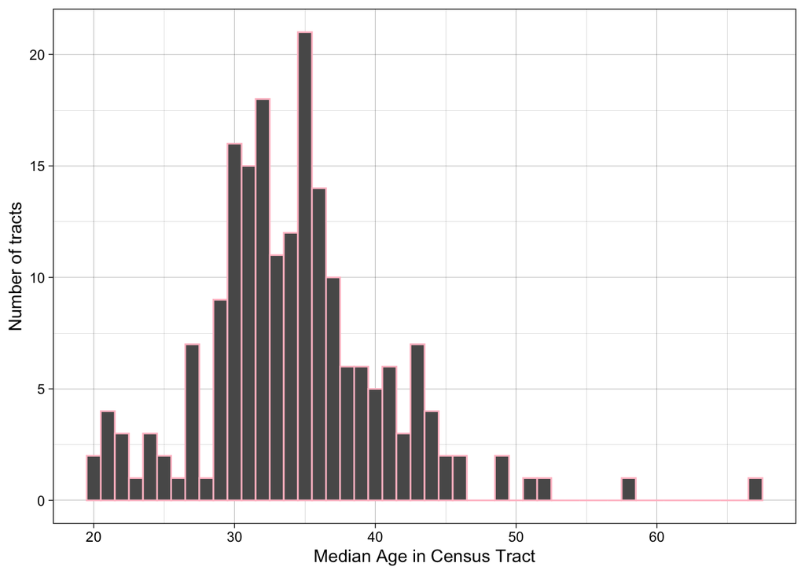

```r
ggplot(tract_data, aes(x = med_ageE)) +
geom_histogram(color = "pink", binwidth = 1) +
  theme_linedraw() +
  scale_x_continuous(name = "Median Age in Census Tract") +
  scale_y_continuous(name = "Number of tracts")
```

## Internet Access by Tract

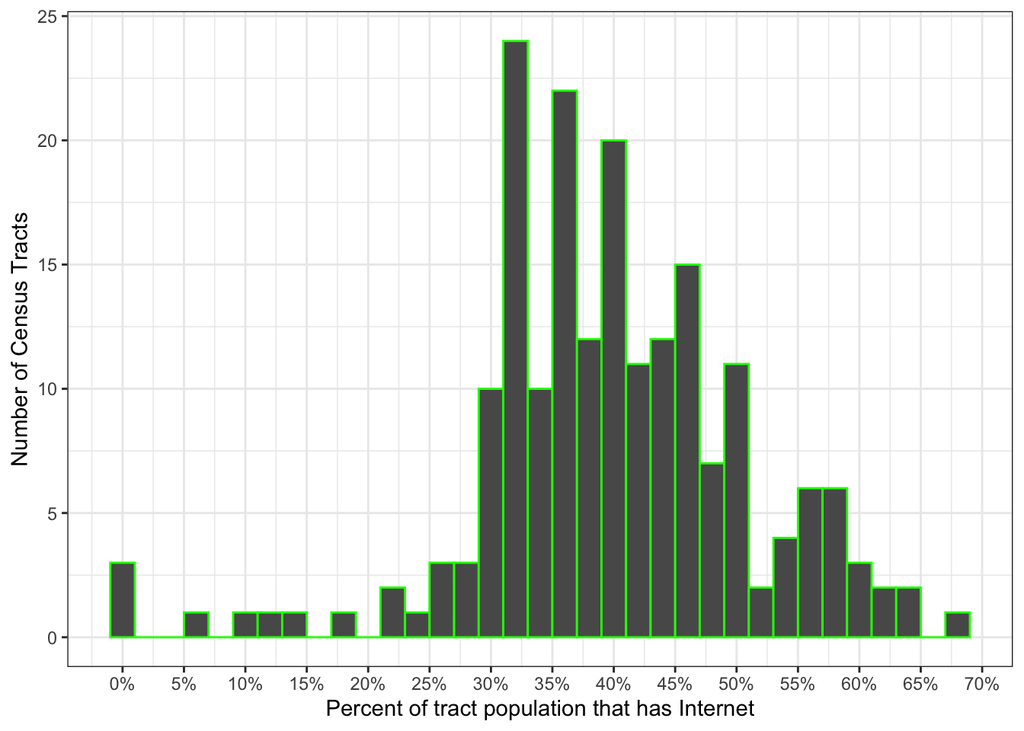

```r
ggplot(tract_data, aes(x = internet_acc)) +
  geom_histogram(color = "green", binwidth = .02) +
  theme_bw() +
  scale_x_continuous(name = "Percent of tract population that has Internet",
                     breaks = breaks <- seq(0, 1, by = 0.05),
                     labels = paste(breaks*100, "%", sep = "")) +
  scale_y_continuous(name = "Number of Census Tracts")
```

Again, this histogram is somewhat normal, but with dramatic and interesting dips in the middle of the histogram. The mean and median of this sample are almost the exact same (39.6% vs 39.2%).

## Total Population by Tract

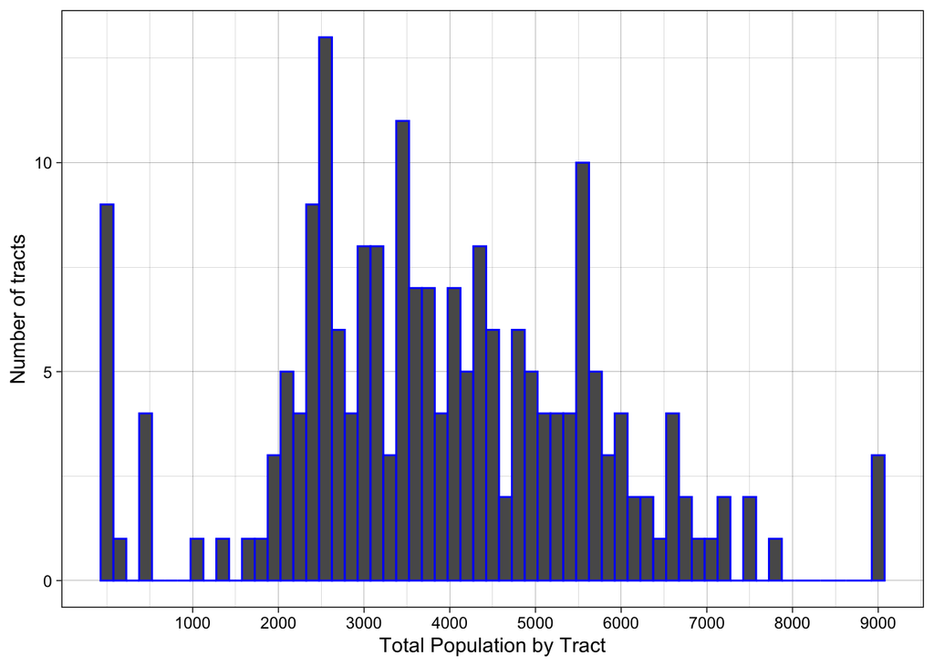

```r
ggplot(tract_data, aes(x = total_popE)) +
geom_histogram(color = "blue", binwidth = 150) +
  theme_linedraw() +
  scale_x_continuous(name = "Total Population by Tract",
                      breaks = breaks <- seq(1000, 9000, by = 1000))+
  scale_y_continuous(name = "Number of tracts")
```

It feels inaccurate to really call this sample’s distribution “normal.” There are quite a few census tracts that are below 1000 people.

# Distribution of Categorical Variables

I’ll now display information about my two categorical variables, which are the percentage of the majority race of each census tract, and nativity by census tract.

## Race/Ethnicity

For whatever reason, my race/ethnicity data didn’t display as [1], [2], [3], etc. and only displayed all the varibles under [1], as seen below. I tried to problem solve this for a while so I could display this as a table, as I did with my other variables above, but eventually decided to show it in a more simple format.

```r
unique(maj_race)
```

```
## [1] "white"       "no_majority" "black"       "latino"      "asian"
```

```r
table(MA_tracts$maj_race)
```

```
##
##       asian       black      latino no_majority       white
##           1          31          15          57         100
```

```r
table(MA_tracts$maj_race) / sum(table(MA_tracts$maj_race))
```

```
##
##       asian       black      latino no_majority       white
## 0.004901961 0.151960784 0.073529412 0.279411765 0.490196078
```

```r
t.test(MA_tracts$maj_race == "asian")
```

```
##
##  One Sample t-test
##
## data:  MA_tracts$maj_race == "asian"
## t = 1, df = 203, p-value = 0.3185
## alternative hypothesis: true mean is not equal to 0
## 95 percent confidence interval:
##  -0.004763328  0.014567249
## sample estimates:
##   mean of x
## 0.004901961
```

```r
t.test(MA_tracts$maj_race == "black")
```

```
##
##  One Sample t-test
##
## data:  MA_tracts$maj_race == "black"
## t = 6.0312, df = 203, p-value = 7.584e-09
## alternative hypothesis: true mean is not equal to 0
## 95 percent confidence interval:
##  0.1022820 0.2016395
## sample estimates:
## mean of x
## 0.1519608
```

```r
t.test(MA_tracts$maj_race == "latino")
```

```
##
##  One Sample t-test
##
## data:  MA_tracts$maj_race == "latino"
## t = 4.0139, df = 203, p-value = 8.401e-05
## alternative hypothesis: true mean is not equal to 0
## 95 percent confidence interval:
##  0.03740978 0.10964905
## sample estimates:
##  mean of x
## 0.07352941
```

```r
t.test(MA_tracts$maj_race == "no_majority")
```

```
##
##  One Sample t-test
##
## data:  MA_tracts$maj_race == "no_majority"
## t = 8.8721, df = 203, p-value = 3.754e-16
## alternative hypothesis: true mean is not equal to 0
## 95 percent confidence interval:
##  0.2173159 0.3415077
## sample estimates:
## mean of x
## 0.2794118
```

```r
t.test(MA_tracts$maj_race == "white")
```

```
##
##  One Sample t-test
##
## data:  MA_tracts$maj_race == "white"
## t = 13.971, df = 203, p-value < 2.2e-16
## alternative hypothesis: true mean is not equal to 0
## 95 percent confidence interval:
##  0.4210156 0.5593765
## sample estimates:
## mean of x
## 0.4901961
```

## Nativity

```r
lar_for <- t.test(large_foreign)
lar_not_for <- t.test(!large_foreign)

tract_for <- tibble(`Majority nativity` = c("Native born","Foreign born"),
                     `Sample proportion` =
                       c(paste(prettyNum(lar_for$estimate*100,
                                         digits = 3), "%"),
                         paste(prettyNum(lar_for$estimate*100,
                                         digits = 3), "%")),
                      `95-percent confidence interval` =
                        c(paste(prettyNum(lar_not_for$conf.int[1]*100,
                                          digits = 3), "% to ",
                                prettyNum(lar_not_for$conf.int[2]*100,
                                          digits = 3), "%"),
                         paste(prettyNum(lar_for$conf.int[1]*100,
                                          digits = 3), "% to ",
                                prettyNum(lar_for$conf.int[2]*100,
                                          digits = 3), "%")))
knitr::kable(tract_for, caption = "Percentage of people Native or Foreign Born in Suffolk County")
```

Percentage of people Native or Foreign Born in Suffolk County

[output not shown]